# Crash course on machine learning on WEkEO data

# Random forest on a forest...?

Welcome to this notebook! Here you will learn how to train a popular class of machine learning model and use [WEkEO](https://www.wekeo.eu/) data to estimate forest canopy.

[figure not shown]

Photograph by Geekstreet. [CC BY-SA 4.0](https://commons.wikimedia.org/w/index.php?curid=65098797)

## The steps...

We will access and analyse data from the WEkEO HDA API Client using the following steps:

1. Download data: We will demonstrate how to download data from the Wekeo API client, then download some pre-prepared data from the Wekeo data viewer.
2. Prepare and explore data: Prepare the data by reformatting and averaging it. Visualize the data and begin to explore corellations semi-manually.
3. Model the data: Build and run a random forest model.

```python
# import all packages

import glob
import os
import datetime
import logging
from zipfile import ZipFile
import numpy as np
import pandas as pd
import netCDF4 as nc
from netCDF4 import Dataset
import xarray as xr
import rasterio
import rasterio.plot
import rasterio.merge
import matplotlib.pyplot as plt
import matplotlib.dates as mdates
import sklearn
from sklearn.ensemble import RandomForestRegressor

# set up logging
logger = logging.getLogger()
logger.setLevel(logging.WARNING)
```

```python
# we require the module seaborn in version >= 0.11
%conda install --yes -q seaborn=0.11
```

```
Solving environment: ...working... done

# All requested packages already installed.
```

```python
# In WEkEO Jupyterhub this is needed to make sure we import the correct version of seaborn
import importlib.util
import sys
spec = importlib.util.spec_from_file_location("seaborn", "/opt/conda/lib/python3.8/site-packages/seaborn/__init__.py")
sns = importlib.util.module_from_spec(spec)
sys.modules["seaborn"] = sns
spec.loader.exec_module(sns)

sns.set_style()
sns.set(font_scale=1.15)
```

```python
bbox = [136.4, -36.1, 138.2, -35.5]  # bounding box of our area of interest
```

## Part 1: Download the data

We will get data about how vegetated the island we are studying is from FCover, the 10-daily fraction-of-vegetation-cover product.

### Download your first data

Firstly, input your WEkEO credentials below. Alternatively, if you have set up a .hdarc file [(instructions)](https://www.wekeo.eu/docs/hda-python-lib) you can skip this step. Then we can set up the API client that lets us run WEkEO downloads

```python
user = 'YourName'   # your WekEO username in quotes
password = 'password' # your WekEO password in quotes
```

```python
pip install -U hda
```

```python
from hda import Client

try:
    c = Client(url='https://wekeo-broker.apps.mercator.dpi.wekeo.eu/databroker', user=user, password=password, debug=True)
except NameError:
    c = Client(debug=True)
```

This is the query we'll send to the client. Use the [WEkEO DATA](https://wekeo.eu/data?view=catalogue) viewer as a helper if you ever want to make other queries for your own projects.

```python
query = {
  "datasetId": "EO:CLMS:DAT:CGLS_GLOBAL_FCOVER300_V1_333M",
  "dateRangeSelectValues": [
    {
      "name": "dtrange",
      "start": "2018-01-01T00:00:00.000Z",
      "end": "2018-01-11T23:59:59.999Z"
    }
  ]
}
```

```python
matches = c.search(query)
print(matches)
matches.download()
```

```
SearchResults[items=1,volume=1.8G,jobId=FtrocVUMrfJPjzXo8fvsxg9kQTA]
```

### Find the file, subset and plot it

```python
fcover_file = glob.glob("*FCOVER300_20180310*.nc")[0]
ds_canopy = xr.open_dataset(fcover_file)
ds_canopy = ds_canopy.sortby(['lat', 'lon'])
```

```python
ds_canopy = ds_canopy["FCOVER"].sel(lon=slice(bbox[0], bbox[2]), lat=slice(bbox[1], bbox[3]))
```

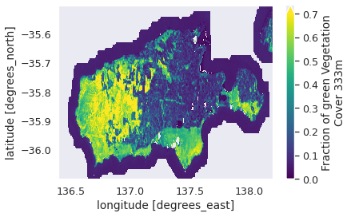

```python
ds_canopy.plot(vmax=0.7)
```

### Download the rest of the data

So far we have downloaded data for one 10-day period. We need more data because we want to use all of the Forest Cover data from 2011 to 2019. To save time on this step, we have pre-prepared the data we need. We can download it in two csv files and load them directly into pandas.

The canopy.csv file is 98 MB and the meteo.csv file is 343 MB so it will take a few minutes to complete the downloads.

Use the dropbox link below to download

```python
canopy_dt = pd.read_csv('http://webdefence.global.blackspider.com/urlwrap/?q=AXicHY1BCsIwEAAX8T0JiUWjIAreCvqHmGgb3GZjUps2z_ERvs_qYS7DwCxP8AaAz0zESa4bluLAOu3QkO8jITPUgVSyrmQ9CqEqtYIzu9yKO7Yxa0TnmztF--_avg9px3nOmdlI4Urjz_PErXgUV1qk12ab5ZMb7SlMzKThYHEv5r1dAHwBdrAtVQ&Z')
canopy_dt = canopy_dt[['time','lon','lat','FCOVER']]
```

That's the vegetation cover data, now get meteorological data for the island:

```python
meteo_dt = pd.read_csv('http://webdefence.global.blackspider.com/urlwrap/?q=AXicHY1RCgIhFAAf0XkUdSkJoqC_hbrDttquofuWp6l1nA7R-dr6mJ9hYNYneAPAZ4H8U24GFimz0Dnf45QIPesxgNSybWRbhdCNVnBmF_tyx5FK572bhhuS-XdjSnPccV5KYYZwvmL9eR75Vgv1QKmqQJHvxINNFlkf88H4vVjuZgXwBSX1K_0&Z')
meteo_dt = meteo_dt[['time','longitude','latitude','t2m','tp','u10','v10']]
```

We converted the temperature from Kelvin to Celcius and saved it all to a csv file.

# Part 2: Prepare and explore the data

```python
meteo_dt.head()
```

|  | time | longitude | latitude | t2m | tp | u10 | v10 |
| --- | --- | --- | --- | --- | --- | --- | --- |
| 0 | 2011-10-01 00:00:00 | 136.399994 | -35.599998 | 15.003021 | 0.000027 | 0.763832 | 8.570405 |
| 1 | 2011-10-01 01:00:00 | 136.399994 | -35.599998 | 15.315308 | 0.000036 | 0.258831 | 8.050105 |
| 2 | 2011-10-01 02:00:00 | 136.399994 | -35.599998 | 15.486237 | 0.000029 | -0.586782 | 7.643668 |
| 3 | 2011-10-01 03:00:00 | 136.399994 | -35.599998 | 15.637054 | 0.000031 | -0.878011 | 7.249296 |
| 4 | 2011-10-01 04:00:00 | 136.399994 | -35.599998 | 15.728516 | 0.000041 | -0.999779 | 7.025718 |

This data needs some preparation before we analyse it.

```python
# find the mean for each hourly timestep (average over the 24 pixels with different latitudes and longitudes)
meteo_dt = meteo_dt.groupby(['time']).mean()
meteo_dt.index = pd.to_datetime(meteo_dt.index)
```

```python
# We need to decide how we will aggregate to daily scale from hourly,
# for the temperature & wind we calculate the daily mean and for the precipitation the sum
t2m_mean = meteo_dt['t2m'].resample('1D').mean()  # 1D means one day
tp_sum = meteo_dt['tp'].resample('1D').sum()
u10_mean = meteo_dt['u10'].resample('1D').mean()
v10_mean = meteo_dt['v10'].resample('1D').mean()
```

Merge the new meteo daily variables together

```python
meteo_daily = pd.concat([t2m_mean, tp_sum, u10_mean, v10_mean], axis=1)
```

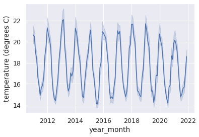

```python
# the graph looks very full if we plot every datapoint, so we'll plot the mean and bounds for each month
meteo_to_plot = meteo_daily.copy()
meteo_to_plot['year_month'] = meteo_to_plot.index.to_period('M').to_timestamp()
sns.lineplot(x='year_month', y='t2m', data=meteo_to_plot)
plt.ylabel('temperature (degrees C)');
```

```python
# find the mean of the canopy cover by time (so instead of having one value per time per longitude per latitude we have one per time)
canopy_dt = canopy_dt.groupby(['time'])[['FCOVER']].mean().reset_index()
canopy_dt['time'] =  pd.to_datetime(canopy_dt['time'], format='%Y-%m-%d')
```

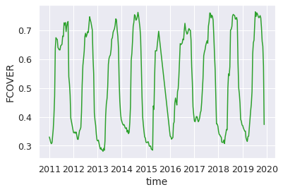

```python
sns.lineplot(x='time', y='FCOVER', data=canopy_dt, color='tab:green')
```

```python
# merge meteo dt and canopy_dt by time
dt_combined = pd.merge(meteo_daily, canopy_dt, on=['time'])
```

### Start exploring correlations between the variables

Can we see any relationships between the variables? Start by plotting a heatmap of their corellation.

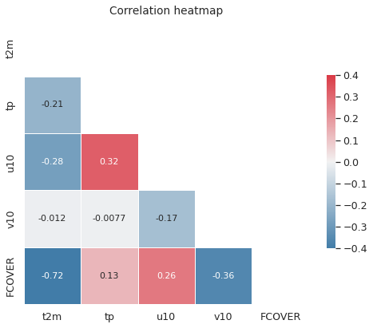

```python
corr = dt_combined.corr()
mask = np.triu(np.ones_like(corr, dtype=bool))
cmap = sns.diverging_palette(240, 10, as_cmap=True)
plt.figure(figsize = (8, 8))
with sns.axes_style("white"):
    sns.heatmap(corr, mask=mask, cmap=cmap, vmax=0.4, vmin=-0.4,
                square=True, linewidths=.5, cbar_kws={"shrink": .5},
                annot=True, annot_kws={'size':11})
    plt.title('Correlation heatmap')
```

Now look at these relationships for the individual datapoints:

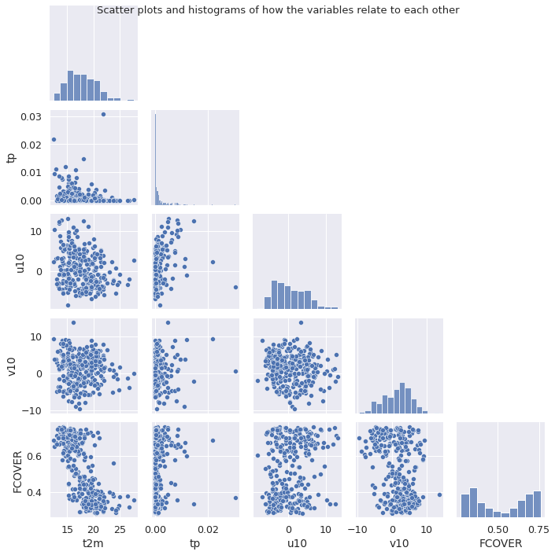

```python
# if this throws an error your environment has an old version of seaborn.
sns.pairplot(dt_combined, corner=True, height=2)
plt.suptitle('Scatter plots and histograms of how the variables relate to each other', size=13);
```

# Part 3: Build a random forest model

We have seen some correlations, in this part of the notebook we will move to more advanced methods. We will apply a random forest to see if we can predict the fraction of canopy cover in the area using only the 4 meteorological variables.

First we need to divide our dataset into train and validation sets. We split the data set based on time, at the moment we have data from 2011 to 2019/12. We use data from 2011 to 2016 to train our model and data from 2017 to 2019 to validate the performance of the model.

```python
train_data = dt_combined[dt_combined['time'] <= '2016-12-31']
valid_data = dt_combined[dt_combined['time'] > '2016-12-31']
```

```python
# first we need to create a Random forest  object
regressor = RandomForestRegressor()
```

```python
# then we fit the model using the training dataset
regressor.fit(train_data[['t2m','tp','u10','v10']], train_data['FCOVER']);
```

Then we predict canopy for 2017 onwards (the validation dataset)

```python
canopy_pred = regressor.predict(valid_data[['t2m','tp','u10','v10']])
```

Plot the predicted versus the actual FCOVER

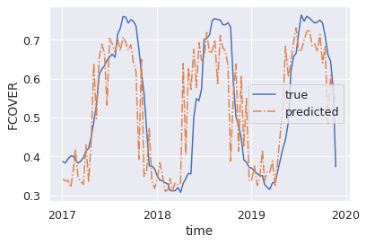

```python
ax = sns.lineplot(x=valid_data['time'], y=valid_data['FCOVER'], label="true")
sns.lineplot(x=valid_data['time'], y=canopy_pred, label="predicted", linestyle="-.", ax=ax)

myFmt = mdates.DateFormatter('%Y')
locator = mdates.YearLocator()
ax.xaxis.set_major_formatter(myFmt)
ax.xaxis.set_major_locator(locator)
```

```python
# to validate how good the prediction of random forest is we calculate the RMSE
rmse = np.sqrt(np.sum((canopy_pred-valid_data['FCOVER'].values)**2)/len(canopy_pred))
print("RMSE = ", rmse)
```

```
RMSE =  0.0998059379926272
```

### Qustions?

Question: What factors stop the RMSE from being zero?  
Question: Can you think of other applications of random forest models in Earth Observation?

### That's the end! What other ways can we use this ML method?